Last update: 05, February, 2023

Please note that we didn’t want to overcrowd the Rmd file, that’s why here we are including only the plots that we were interested to discuss, otherwise we did a detailed, quick, not-really-pretty visualization in [python](https://colab.research.google.com/drive/1641tlYuIDA7OtZse1xh3H9-4-%20gBQ_9ZH#scrollTo=OAi83G-ey2HN) for every variable as it relates to the others.

```r
# First of all run all the necessary libraries for both exercises

## Common libraries:
  # To do the plots
library(ggplot2)
  # Allow to modify the tables
library(dplyr)
  # Add more themes in the plots
library(ggthemes)
  # To merge different plots in a single plot
library(cowplot)

## First exercise:
  # To impute the missing values
library(mice)
  # To do the plots of the Univariate and Bivariate analysis
library(tidyr)
  # To do correlograms
library(GGally)

## Second exercise:
  # To import excel files
library(openxlsx)
  # Visualize and modify the table of Figure 1B
library(gridExtra)
  # To add the colour palette of the heatmap
library(RColorBrewer)
  # To do the second heatmap
library(ComplexHeatmap)
```

# **1. Analysis of the Heart Disease Dataset**

Load the data from [here](https://raw.githubusercontent.com/jpinero/DMI_2021/main/datasets/heart_disease_dataset.csv), and the description is [here](https://raw.githubusercontent.com/jpinero/DMI_2021/main/datasets/heart_disease_description.txt). The original dataset comes from [here](https://archive.ics.uci.edu/ml/datasets/Heart+Disease) and corresponds to the [processed cleveland data](https://archive.ics.uci.edu/ml/machine-learning-databases/heart-disease/processed.cleveland.data)

## **1.1. Perform an EDA on the dataset**

To perform the EDA we follow several steps:

- Collect, clean and prepare the data for analysis by handling missing values, removing outliers, and transforming variables as necessary
- Perform an univariate and bivariate analysis. Visualizations
- Conclusions

### **Step 1: Collect, clean and prepare the data**

#### **a) Our data**

First we load our data using ‘read.table’ function and assign it to a variable called *heart_disease_table*. We use it because .csv files use spaces to separate data and this function transform it into a readable table.

```r
heart_disease_table <-read.table("./heart_disease_dataset.csv",
                                 header=TRUE,
                                 na.strings = "?")

# By using na.strings we can transform "?" into NAs
# in order to allow the recognition of the missing values
```

Now we have our initial table, we can take a first look and get to know some of the characteristics of the variables:

```r
summary(heart_disease_table)
```

```
##       age             sex               cp           trestbps
##  Min.   :29.00   Min.   :0.0000   Min.   :1.000   Min.   : 94.0
##  1st Qu.:48.00   1st Qu.:0.0000   1st Qu.:3.000   1st Qu.:120.0
##  Median :56.00   Median :1.0000   Median :3.000   Median :130.0
##  Mean   :54.44   Mean   :0.6799   Mean   :3.158   Mean   :131.7
##  3rd Qu.:61.00   3rd Qu.:1.0000   3rd Qu.:4.000   3rd Qu.:140.0
##  Max.   :77.00   Max.   :1.0000   Max.   :4.000   Max.   :200.0
##
##       chol            fbs            restecg          thalach
##  Min.   :126.0   Min.   :0.0000   Min.   :0.0000   Min.   : 71.0
##  1st Qu.:211.0   1st Qu.:0.0000   1st Qu.:0.0000   1st Qu.:133.5
##  Median :241.0   Median :0.0000   Median :1.0000   Median :153.0
##  Mean   :246.7   Mean   :0.1485   Mean   :0.9901   Mean   :149.6
##  3rd Qu.:275.0   3rd Qu.:0.0000   3rd Qu.:2.0000   3rd Qu.:166.0
##  Max.   :564.0   Max.   :1.0000   Max.   :2.0000   Max.   :202.0
##
##      exang           oldpeak         slope             ca
##  Min.   :0.0000   Min.   :0.00   Min.   :1.000   Min.   :0.0000
##  1st Qu.:0.0000   1st Qu.:0.00   1st Qu.:1.000   1st Qu.:0.0000
##  Median :0.0000   Median :0.80   Median :2.000   Median :0.0000
##  Mean   :0.3267   Mean   :1.04   Mean   :1.601   Mean   :0.6722
##  3rd Qu.:1.0000   3rd Qu.:1.60   3rd Qu.:2.000   3rd Qu.:1.0000
##  Max.   :1.0000   Max.   :6.20   Max.   :3.000   Max.   :3.0000
##                                                  NA's   :4
##       thal            num           patient_id
##  Min.   :3.000   Min.   :0.0000   Min.   :  1.0
##  1st Qu.:3.000   1st Qu.:0.0000   1st Qu.: 76.5
##  Median :3.000   Median :0.0000   Median :152.0
##  Mean   :4.734   Mean   :0.9373   Mean   :152.0
##  3rd Qu.:7.000   3rd Qu.:2.0000   3rd Qu.:227.5
##  Max.   :7.000   Max.   :4.0000   Max.   :303.0
##  NA's   :2
```

```r
str(heart_disease_table)
```

```
## 'data.frame':    303 obs. of  15 variables:
##  $ age       : int  63 67 67 37 41 56 62 57 63 53 ...
##  $ sex       : int  1 1 1 1 0 1 0 0 1 1 ...
##  $ cp        : int  1 4 4 3 2 2 4 4 4 4 ...
##  $ trestbps  : int  145 160 120 130 130 120 140 120 130 140 ...
##  $ chol      : int  233 286 229 250 204 236 268 354 254 203 ...
##  $ fbs       : int  1 0 0 0 0 0 0 0 0 1 ...
##  $ restecg   : int  2 2 2 0 2 0 2 0 2 2 ...
##  $ thalach   : int  150 108 129 187 172 178 160 163 147 155 ...
##  $ exang     : int  0 1 1 0 0 0 0 1 0 1 ...
##  $ oldpeak   : num  2.3 1.5 2.6 3.5 1.4 0.8 3.6 0.6 1.4 3.1 ...
##  $ slope     : int  3 2 2 3 1 1 3 1 2 3 ...
##  $ ca        : int  0 3 2 0 0 0 2 0 1 0 ...
##  $ thal      : int  6 3 7 3 3 3 3 3 7 7 ...
##  $ num       : int  0 2 1 0 0 0 3 0 2 1 ...
##  $ patient_id: int  1 2 3 4 5 6 7 8 9 10 ...
```

Looking at the results, we see that we have 15 variables and 303 observations. The differences between the values associated with sex is evident, there are many more men than women in this dataset. In addition, if we look at the minimum and maximum values, we can see that in some variables there is a large difference between them (chol, trestbps and thalach). Later on we will go deeper into this and we will see if there can be any outlier.

By running the last commands, we see that most of them are integer variables, except *oldpeaks* which is numerical. In addition, we observe that in the *ca* and *thal* columns there are 4 and 2 missing values, respectively.

However, if we look for the description of each variable within the file *heart_disease_description.txt*, we realize that some of these integers are associated to a categorical variable:

- **sex**: 1 = male; 0 = female
- **cp**: chest pain type
  - Value 1: typical angina
  - Value 2: atypical angina
  - Value 3: non-anginal pain
  - Value 4: asymptomatic
- **fbs** (fasting blood sugar > 120 mg/dl): 1 = true; 0 = false
- **restecg**: resting electrocardiographic results
  - Value 0: normal
  - Value 1: having ST-T wave abnormality (T wave inversions and/or ST elevation or depression of > 0.05 mV)
  - Value 2: showing probable or definite left ventricular hypertrophy by Estes’ criteria
- **exang** (exercise induced angina): 1 = yes; 0 = no
- **slope**: the slope of the peak exercise ST segment
  - Value 1: upsloping
  - Value 2: flat
  - Value 3: downsloping
- **ca**: number of major vessels (0-3) colored by flourosopy
- **thal**:
  - 3 = normal
  - 6 = fixed defect
  - 7 = reversable defect
- **num**: diagnosis of heart disease (angiographic disease status)
  - Value 0: < 50% diameter narrowing
  - Value 1: > 50% diameter narrowing

So this are the categorical variables and we have to make sure that they are determined as such. But first, we check if there is any ID repeated and if not, it will mean that each of the data corresponds to different patients.

```r
# Check if there is any ID repeated
duplicated_ID <- heart_disease_table$patient_id[duplicated(heart_disease_table$patient_id)]
duplicated_ID
```

```
## integer(0)
```

As we can see there is no repeated ID in this column, so we will remove it since it is not informative and we will not need it to perform the analysis.

```r
heart_disease_table$patient_id <- NULL
```

Now we will change each numerical value by its corresponding categorical value.

#### **b) Missing values**

As we have said before, there are some **missing values** in the *ca* and *thal* column After modifying our *heart_disease_table* they should still be there, let’s check it.

```r
NA_count_by_column <- colSums(is.na(heart_disease_table))
print(NA_count_by_column)
```

```
##      age      sex       cp trestbps     chol      fbs  restecg  thalach
##        0        0        0        0        0        0        0        0
##    exang  oldpeak    slope       ca     thal      num
##        0        0        0        4        2        0
```

```r
# Save this table in a second variable
first_modified_table <- heart_disease_table
```

As expected we still have these values, so we are going to impute them using the **package mice**. We save our table in a new variable before performing the imputation, just in case we have to come back to this point.

By this imputation step we will replace the missing values with an substituted, best guess value. In this case, we use [mice](https://cran.r-project.org/web/packages/mice/mice.pdf) package because allows us to do this imputation assuming that our missing value is a Missing at Random (MAR).

```r
# check again if there are missing values
NA_count_check <- colSums(is.na(completed_data))
print(NA_count_check)
```

```
##      age      sex       cp trestbps     chol      fbs  restecg  thalach
##        0        0        0        0        0        0        0        0
##    exang  oldpeak    slope       ca     thal      num
##        0        0        0        0        0        0
```

As we expect, there is no missing value now, so lets continue with the outliers.

#### **c) Outliers**

In order to check the outliers, we will represent the data using histograms and boxplots and see it there is any extreme value. We use the [ggplot2](https://cran.r-project.org/web/packages/ggplot2/index.html) package.

We will do the plots for those variables that are numeric: age, trestbps, chol, thalach and oldpeak. Then, we use the package [**cowplot**](https://cran.r-project.org/web/packages/cowplot/vignettes/introduction.html) to merge all of them in a single plot.

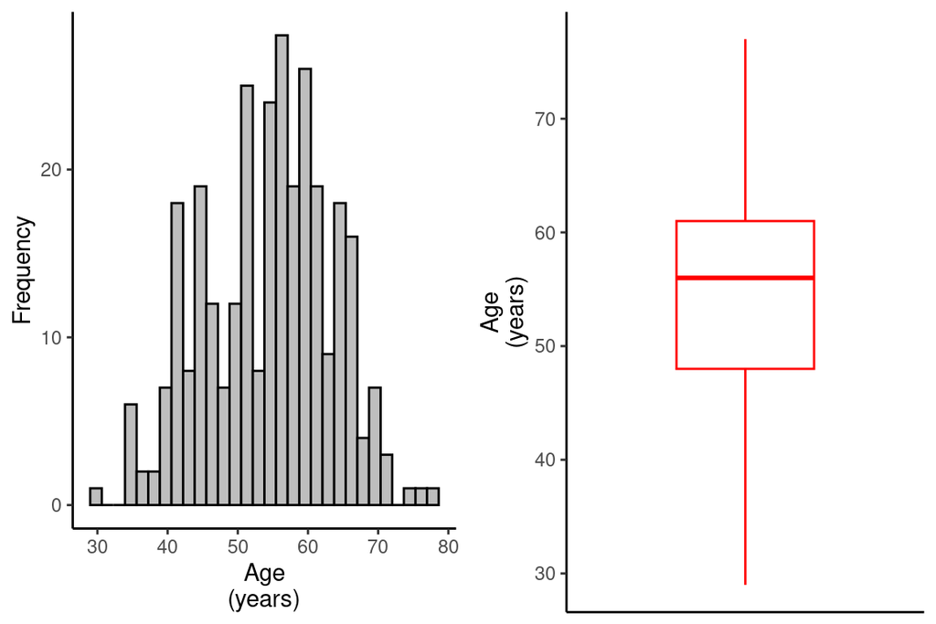

```r
age_boxplot <- ggplot(completed_data, aes(y = age)) +
  geom_boxplot(color = "red", outlier.color = "black") +
  ylab ("Age\n(years)") +
  scale_x_discrete() +
  theme_classic()

age_barplot <- ggplot(completed_data, aes(x = age)) +
  geom_histogram(color = "black", fill = "grey") +
  xlab("Age\n(years)") +
  ylab("Frequency") +
  scale_x_continuous() +
  theme_classic()

# Merge the age plots
age_plots <- list(age_barplot, age_boxplot)
plot_grid(plotlist = age_plots)
```

There is no outlier in Age variable.

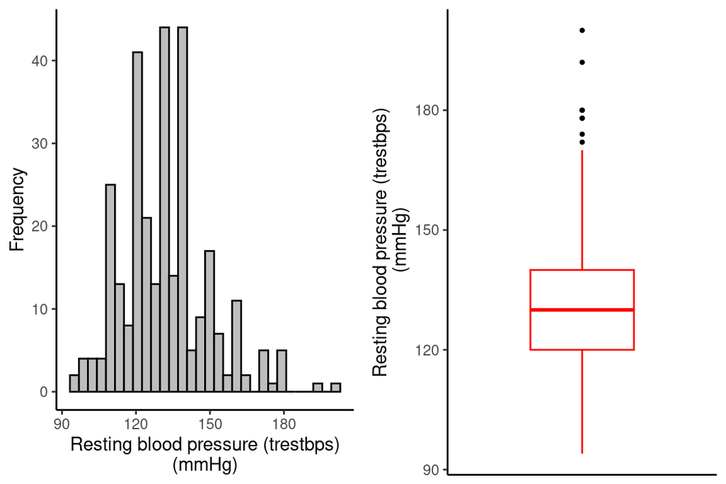

```r
trestbps_boxplot <- ggplot(completed_data, aes(y = trestbps)) +
  geom_boxplot(color = "red", outlier.color = "black", outlier.size = 0.8) +
  ylab ("Resting blood pressure (trestbps)\n (mmHg)") +
  scale_x_discrete() +
  theme_classic()


trestbps_barplot <- ggplot(completed_data, aes(x = trestbps)) +
  geom_histogram(color = "black", fill = "grey") +
  xlab("Resting blood pressure (trestbps)\n (mmHg) ") +
  ylab("Frequency") +
  scale_x_continuous() +
  theme_classic()

# Merge the age plots
trestbps_plots <- list(trestbps_barplot, trestbps_boxplot)

plot_grid(plotlist = trestbps_plots)
```

It seems that there is some extreme values

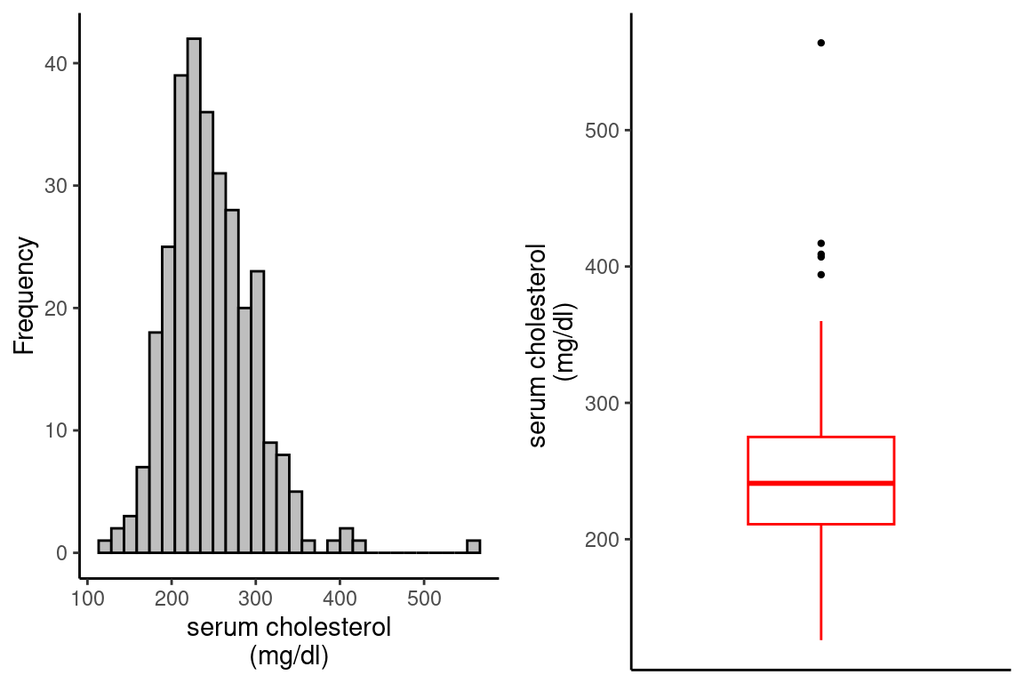

```r
chol_boxplot <- ggplot(completed_data, aes(y = chol)) +
  geom_boxplot(color = "red", outlier.color = "black", outlier.size = 0.8) +
  ylab ("serum cholesterol \n(mg/dl)") +
  scale_x_discrete() +
  theme_classic()

chol_barplot <- ggplot(completed_data, aes(x = chol)) +
  geom_histogram(color = "black", fill = "grey") +
  xlab("serum cholesterol\n(mg/dl)") +
  ylab("Frequency") +
  scale_x_continuous() +
  theme_classic()

# Merge the chol plots
chol_plots <- list(chol_barplot, chol_boxplot)
plot_grid(plotlist = chol_plots)
```

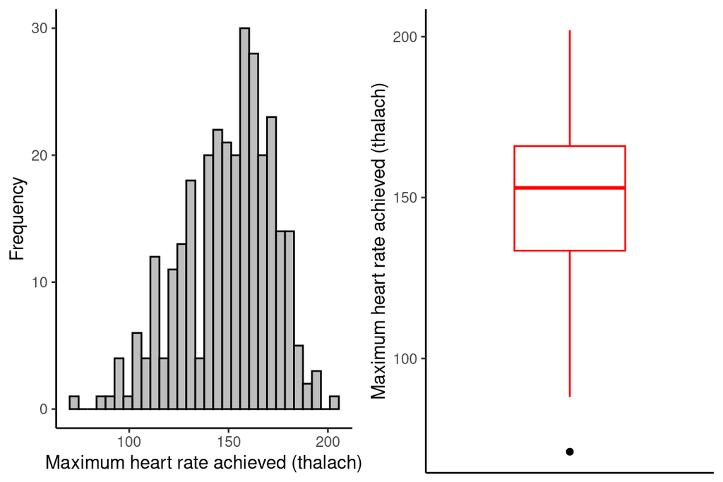

```r
thalach_boxplot <- ggplot(completed_data, aes(y = thalach)) +
  geom_boxplot(color = "red", outlier.color = "black") +
  ylab ("Maximum heart rate achieved (thalach)") +
  scale_x_discrete(labels = NULL) +
  theme_classic()

thalach_barplot <- ggplot(completed_data, aes(x = thalach)) +
  geom_histogram(color = "black", fill = "grey") +
  xlab("Maximum heart rate achieved (thalach)") +
  ylab("Frequency") +
  scale_x_continuous() +
  theme_classic()

# Merge the thalach plots
thalach_plots <- list(thalach_barplot, thalach_boxplot)
plot_grid(plotlist = thalach_plots)
```

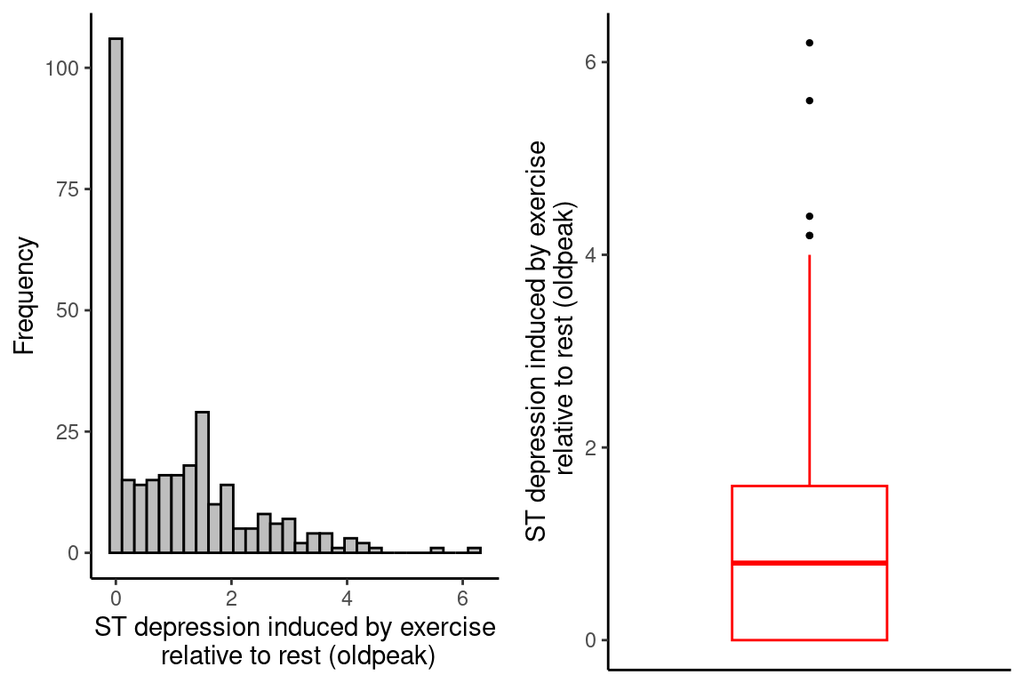

```r
oldpeak_boxplot <- ggplot(completed_data, aes(y = oldpeak)) +
  geom_boxplot(color = "red", outlier.color = "black", outlier.size = 0.8) +
  ylab ("ST depression induced by exercise\n relative to rest (oldpeak)") +
  scale_x_discrete(labels = NULL) +
  theme_classic()


oldpeak_barplot <- ggplot(completed_data, aes(x = oldpeak)) +
  geom_histogram(color = "black", fill = "grey") +
  xlab("ST depression induced by exercise\n relative to rest (oldpeak)") +
  ylab("Frequency") +
  scale_x_continuous() +
  theme_classic()

# Merge the oldpeak plots
oldpeak_plots <- list(oldpeak_barplot, oldpeak_boxplot)
plot_grid(plotlist = oldpeak_plots)
```

So as we can see in the plots, the variables **trestbps, chol, thalach and oldpeak** have some outliers. We also check some of this extreme values using the ‘tail function’ or we can observe the distribution of this variable using the ‘summary’ function:

```r
cols <- c('age','trestbps','chol','thalach','oldpeak')
summary(heart_disease_table[cols])
```

```
##       age           trestbps          chol          thalach         oldpeak
##  Min.   :29.00   Min.   : 94.0   Min.   :126.0   Min.   : 71.0   Min.   :0.00
##  1st Qu.:48.00   1st Qu.:120.0   1st Qu.:211.0   1st Qu.:133.5   1st Qu.:0.00
##  Median :56.00   Median :130.0   Median :241.0   Median :153.0   Median :0.80
##  Mean   :54.44   Mean   :131.7   Mean   :246.7   Mean   :149.6   Mean   :1.04
##  3rd Qu.:61.00   3rd Qu.:140.0   3rd Qu.:275.0   3rd Qu.:166.0   3rd Qu.:1.60
##  Max.   :77.00   Max.   :200.0   Max.   :564.0   Max.   :202.0   Max.   :6.20
```

Taking into account all this information we can conclude that **chol** and **oldpeak** variables have the most extreme values, because as we can see in the quartiles:

So, we focus on them and we replace their outliers with the closest value within the specified range for each variable instead of remove them.

```r
# Check the last 10 values of this variable
tail(sort(completed_data$chol), n = 10)
```

```
##  [1] 341 342 353 354 360 394 407 409 417 564
```

```r
tail(sort(completed_data$oldpeak), n = 10)
```

```
##  [1] 3.6 3.8 4.0 4.0 4.0 4.2 4.2 4.4 5.6 6.2
```

We can see that for **chol** the deviating values start from around 407, and for ‘oldpeak’ around 4.3. So we will deal with these outliers by setting them to the next biggest value.

```r
chol_max = 407
oldpeak_max = 4.3
```

```r
# Before modifying the table we will store the current table in other variable
before_outliers_data <- completed_data

completed_data$chol[completed_data$chol > chol_max] <- chol_max
completed_data$oldpeak[completed_data$oldpeak > oldpeak_max] <- oldpeak_max

# Now we rename the table:
heart_disease_modified <- completed_data
```

As a note, we first think to modify the outliers using the IQR criterion, but for the chol variable the max_accepted was 371, so by this criterion we see that we modified some values that could be possible in the context of disease, so we prefer to do it by this method.

### **Step 2: Univariate analysis**

In this part of the EDA, we will perform an univariate analysis for continuous and categorical variables in our data without missing values and with modified outliers (called **heart_disease_modified**).

#### a) Numerical variables

The **continuous variables** are: age, trestbps, chol, thalach and oldpeak.

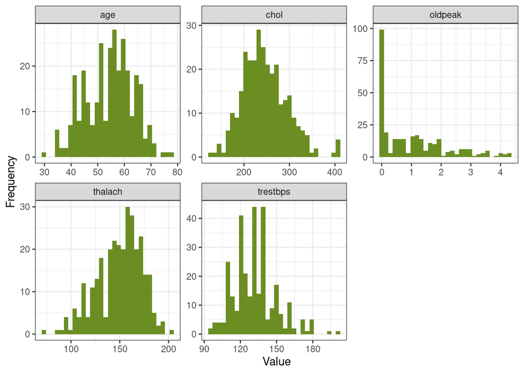

```r
# Continuous variables
cont_vars <- c("age", "trestbps", "chol", "thalach", "oldpeak")

# HISTOGRAMS
heart_disease_modified[,cont_vars] %>%  gather(cols, value) %>%  ggplot(aes(x = value)) +
  geom_histogram(fill = "olivedrab") +
  scale_x_continuous(name = "Value") +
  scale_y_continuous(name = "Frequency") +
  facet_wrap(~ cols, scales = "free") +
  theme_bw()
```

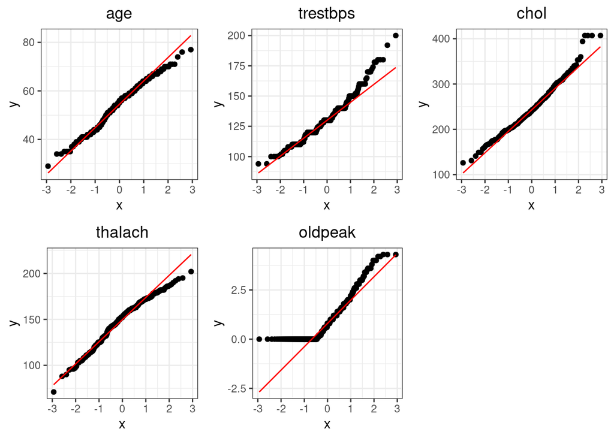

```r
# QQ-PLOTS

age_qqplot <- ggplot(heart_disease_modified, aes(sample = age)) +
  geom_qq() +
  geom_qq_line(color = "red")+
  ggtitle("age") +
  theme_bw() +
  theme(plot.title = element_text(hjust = 0.5))

trestbps_qqplot <- ggplot(heart_disease_modified, aes(sample = trestbps)) +
  geom_qq() +
  geom_qq_line(color = "red")+
  ggtitle("trestbps") +
  theme_bw() +
  theme(plot.title = element_text(hjust = 0.5))

chol_qqplot <- ggplot(heart_disease_modified, aes(sample = chol)) +
  geom_qq() +
  geom_qq_line(color = "red")+
  ggtitle("chol") +
  theme_bw() +
  theme(plot.title = element_text(hjust = 0.5))

thalach_qqplot <- ggplot(heart_disease_modified, aes(sample = thalach)) +
  geom_qq() +
  geom_qq_line(color = "red")+
  ggtitle("thalach") +
  theme_bw() +
  theme(plot.title = element_text(hjust = 0.5))

oldpeak_qqplot <- ggplot(heart_disease_modified, aes(sample = oldpeak)) +
  geom_qq() +
  geom_qq_line(color = "red")+
  ggtitle("oldpeak") +
  theme_bw() +
  theme(plot.title = element_text(hjust = 0.5))

# Create a list to show all the plots together
qqplots <- list(age_qqplot, trestbps_qqplot, chol_qqplot, thalach_qqplot, oldpeak_qqplot)
plot_grid(plotlist = qqplots)
```

With this plots we can check that the variable refered to ‘ST depression induced by exercise relative to rest (oldpeak)’ does not follow a normal distribution, but the others do.

#### b) Categorical variables

The **categorial variables** are: sex, cp, fbs, restecg, exang, slope, thal and num. We separate the variables depending on the number of levels they have. The variables cp, restecg, slope and thal have more than 2 levels and if we represent with the other variables they cannot be clearly distinguished.

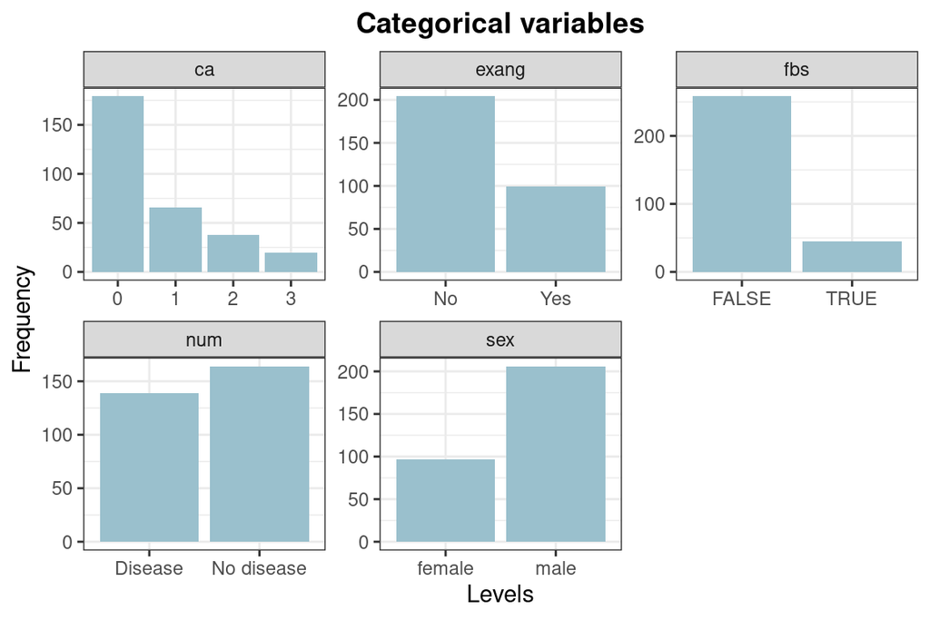

```r
# Categorical variables: clearly distinguished
# BAR PLOTS
cat_vars_clear_levels <- c("sex", "fbs", "exang", "ca", "num")

heart_disease_modified[, cat_vars_clear_levels] %>% gather(cols, value) %>%  ggplot(aes(x = value)) +
  geom_bar(fill = "lightblue3") +
  facet_wrap(~ cols, scales = "free") +
  scale_x_discrete(name = "Levels") +
  scale_y_continuous(name = "Frequency") +
  theme_bw() +
  ggtitle("Categorical variables") +
  theme(plot.title = element_text(face = "bold", hjust = 0.5))
```

The majority of people in this dataset seem to have 0 of major vessels colored by fluoroscopy (ca). And there are twice as many people who do not have exercise induced angina (exang) then those that do. Most of the records in this dataset are with fasting blood sugar (fbs) less 120 mg/dl. And most are male. The ratio between those that have more and less than 50% diameter narrowing in any major vessel is almost 1, but there are more people who have less than 50% diameter narrowing (do not have a heart disease).

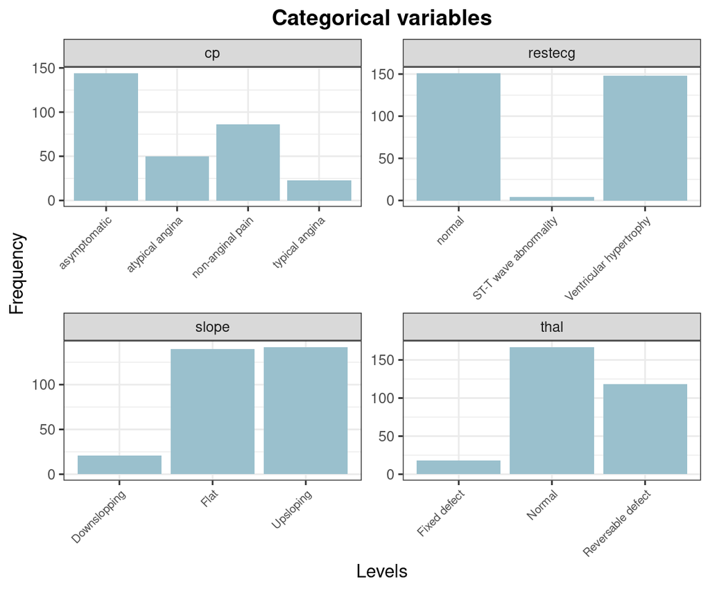

```r
# Categorical variables: not clearly distinguished
# BAR PLOTS
cat_vars_dif_levels <- c("cp", "restecg", "slope", "thal")

heart_disease_modified[, cat_vars_dif_levels] %>% gather(cols, value) %>%  ggplot(aes(x = value)) +
  geom_bar(fill = "lightblue3") +
  facet_wrap(~ cols, scales = "free") +
  scale_x_discrete(name = "Levels") +
  scale_y_continuous(name = "Frequency") +
  theme_bw() +
  ggtitle("Categorical variables") +
  theme(axis.text.x = element_text(angle = 45, hjust = 1, size = 7)) +
  theme(plot.title = element_text(face = "bold", hjust = 0.5))
```

Most people in this dataset are asymptomatic for chest pain. Only a few people have ST-T wave abnormality (T wave inversions and/or ST elevation or depression of > 0.05 mV) – actually only 4 people. For majority of people the slope of the peak exercise ST segment is flat or upsloping. The majority of people have a normal blood flow (thal refers to the blood disorder called thalassemia).

## **1.2. Create visualizations in order to show which variables seem to be more associated with heart disease**

Here we will perform a Bivariate analysis to look for the association of the categorical variable “num” (diagnosis of heart disease) and the other variables (categorical and continuous). By this, we will see the association between the variables with the conditions **Disease** and **No disease**.

### **Step 3: Bivariate analysis**

#### a) Categorical

As we have done in the Univariate analysis we are going to split the categorical variables in two groups just to clarify the results.

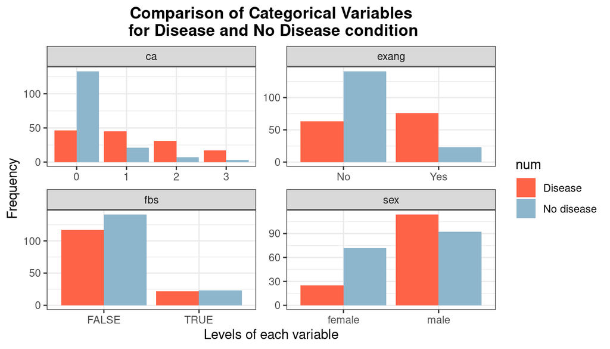

```r
categorical_var_1 <- c("sex", "fbs", "exang", "ca", "num")

heart_disease_modified[, categorical_var_1] %>% gather(cols, value, -num) %>% ggplot(aes(x = value, fill = num)) +
  geom_bar(position = "dodge") +
  facet_wrap(~ cols, scales = "free") +
  scale_fill_manual(values = c("tomato", "lightskyblue3")) +
  xlab("Levels of each variable") + ylab("Frequency") +
  ggtitle("Comparison of Categorical Variables\n for Disease and No Disease condition") +
  theme_bw() +
  theme(plot.title = element_text(face = "bold", hjust = 0.5))
```

Most people who do not have heart disease do not have any major vessels colored by fluoroscopy (ca). The case for people with disease is different. The least amount have 3 ca, but this is because the count of 3 ca is very lot itself. Then the others appear to be evenly distributed between the other categories.

There seem to be a bit more people with a heart condition that experience exercise induced angina than those who do not, but the counts are almost equal. However, there are out of those that do not have exercise induced angina, most do not have a heart disease.

There doesn’t really seem to be a link between having a fasting blood sugar greater than 120 mg/dl and having heart condition.

In this dataset, most of the people who have a heart disease are men and only a few a women.

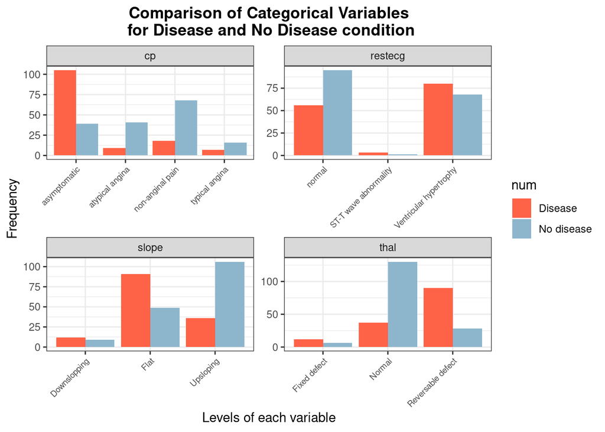

```r
categorical_var_2 <- c("cp", "restecg", "slope", "thal", "num") # we also num to do the plot in function of it

heart_disease_modified[, categorical_var_2] %>% gather(cols, value, -num) %>% ggplot(aes(x = value, fill = num)) +
  geom_bar(position = "dodge") +
  facet_wrap(~ cols, scales = "free") +
  scale_fill_manual(values = c("tomato", "lightskyblue3")) +
  xlab("Levels of each variable") + ylab("Frequency") +
  ggtitle("Comparison of Categorical Variables\n for Disease and No Disease condition") +
  theme_bw() +
  theme(axis.text.x = element_text(angle = 45, hjust = 1, size = 7)) +
  theme(plot.title = element_text(face = "bold", hjust = 0.5))
```

It is interesting to note that most people with a heart disease in this dataset are asymptomatic for their chest pain.

The majority of people without a heart condition have a normal resting electrocardiographic results, but still a significant part are showing probable or definite left ventricular hypertrophy by Estes’ criteria.

Most people without a heart disease in this dataset have an upsloping slope of the peak exercise ST segment. And most people with a heart disease have a flat slop.

The majority of people without a heart condition have a normal {thal}, and most people with a condition have reversible defect.

#### b) Continuous

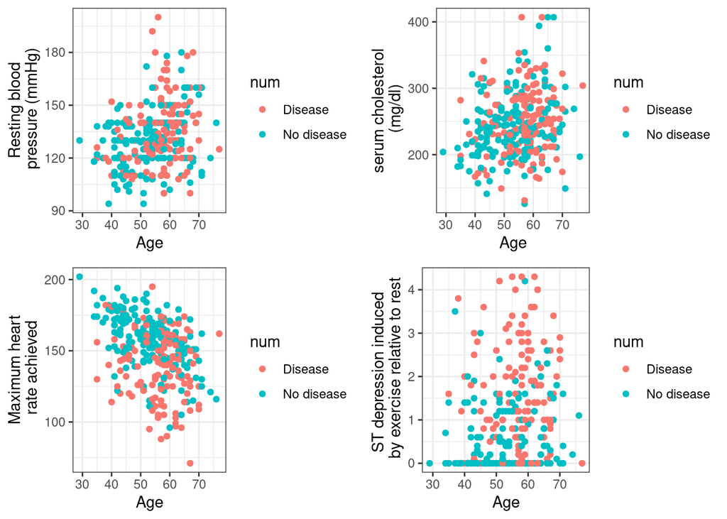

```r
# Continuous variables

age_trestbps <- ggplot(heart_disease_modified, aes(x = age, y = trestbps, color = num)) +
  geom_point(position = "dodge") +
  scale_fill_manual(values = c("tomato", "lightskyblue3")) +
  xlab("Age") + ylab("Resting blood\n pressure (mmHg)") +
  theme_bw()

age_chol <- ggplot(heart_disease_modified, aes(x = age, y = chol, color = num)) +
  geom_point(position = "dodge") +
  scale_fill_manual(values = c("tomato", "lightskyblue3")) +
  xlab("Age") + ylab("serum cholesterol\n (mg/dl)") +
  theme_bw()

age_thalach <- ggplot(heart_disease_modified, aes(x = age, y = thalach, color = num)) +
  geom_point(position = "dodge") +
  scale_fill_manual(values = c("tomato", "lightskyblue3")) +
  xlab("Age") + ylab("Maximum heart\n rate achieved") +
  theme_bw()

age_oldpeak <-ggplot(heart_disease_modified, aes(x = age, y = oldpeak, color = num)) +
  geom_point(position = "dodge") +
  scale_fill_manual(values = c("tomato", "lightskyblue3")) +
  xlab("Age") + ylab("ST depression induced \n by exercise relative to rest") +
  theme_bw()


# Create a list to show all the plots together
bivariate_cont_plot <- list(age_trestbps, age_chol, age_thalach, age_oldpeak )
plot_grid(plotlist = bivariate_cont_plot)
```

#### d) Multivariate analysis

```r
# Age and Resting blood pressure separated by cp and taking into account num (disease and non disease)
sugar_blood = ggplot(completed_data, aes(y = trestbps, x = age, color= num)) +
  geom_point() +
  scale_color_manual(values = c("tomato", "lightskyblue3"),
                     labels = c("Disease", "No disease")) +
  labs(title="Resting blood pressure by cp",
         y="Blood pressure",
         x="Age (years)",
         color="") +
  theme_bw()

sugar_blood <- sugar_blood + geom_smooth(method = "lm", fullrange = TRUE, se = FALSE, color = "black") + facet_grid(. ~ cp)
```

```r
# Serum cholesterol and Resting blood pressure separated by cp and taking into account num (disease and non disease)

trestbps_chol = ggplot(completed_data, aes(y = trestbps, x = chol, color= num)) +
  geom_point() +
  scale_color_manual(values = c("tomato", "lightskyblue3"),
                     labels = c("Disease", "No disease")) +
  labs(title="Resting blood pressure by chol",
         y="Blood pressure",
         x="Serum cholesterol (mg/dl)",
         color="") +
  theme_bw()

trestbps_chol<- trestbps_chol + geom_smooth(method = "lm", fullrange = TRUE, se = FALSE, color = "black") + facet_grid(. ~ cp)
```

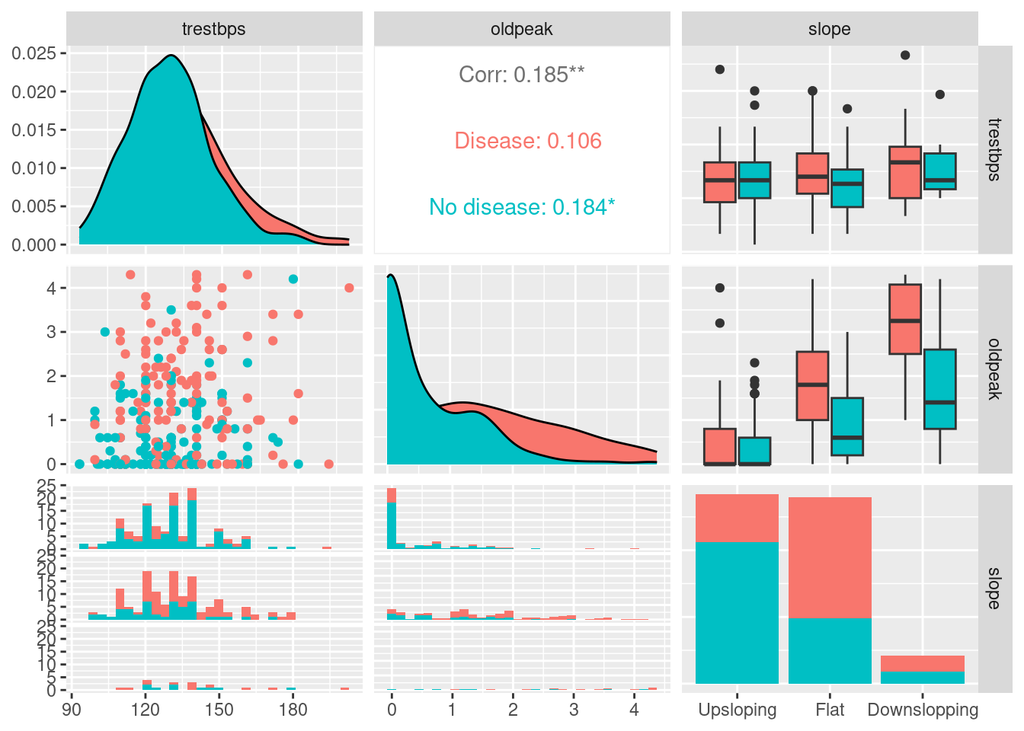

```r
# Use the library (GGally) to do a correlogram
interested_cols <- c("trestbps","oldpeak","slope")

ggpairs(heart_disease_modified, columns = interested_cols, ggplot2::aes(colour=num))
```

We found interesting here that for a given slope the people that have the disease score higher in the distribution of ST depression induced by exercise relative to rest in comparison with those that do not have a heart condition and have the same value for slope.

# **2. Difference in mortality rates in hospitalized COVID-19 patients**

Using the *supplementary material* from the [Difference in mortality rates in hospitalized COVID-19 patients identified by cytokine profile clustering using a machine learning approach: An outcome prediction alternative](https://www.frontiersin.org/articles/10.3389/fmed.2022.987182/full), perform the following tasks

#### Import the data

```r
table_1 <-read.xlsx("Table 1.xlsx", startRow = 2, colNames = TRUE, na.strings = c("NI"," "))
  # na.strings : change the "NI" and empty spaces values to NA

table_2 <-read.xlsx("Table 2.xlsx", startRow = 2, colNames = TRUE, na.strings = c("NI", "ND"), fillMergedCells = TRUE)
# Change the "NI" and "ND" values to NA
```

## **2.1. Reproduce Figure 1 from the publication**

### **How is the data of the table_1?**

#### **Duplicates**

```r
# We check if there is any ID repeated
repeated_IDs <- table_1$ID[duplicated(table_1$ID)]
print(unique(repeated_IDs))
```

```
## [1] "COAG-HSJD-086" "COAG-HSJD-136" "COAG-HSJD-160" "COAG-HSJD-197"
## [5] "COAG-HSJD-222" "COAG-HSJD-225" "COAG-HSJD-243" "COAG-HSJD-244"
```

```r
# Filter the table_1 based on the repeated ID values
filtered_table <- table_1 %>%
  filter(ID %in% repeated_IDs) %>%
  arrange(ID)

filtered_table
```

```
##               ID Age Gender                BMI Syntoms.onset
## 1  COAG-HSJD-086  77      M             24.741         44065
## 2  COAG-HSJD-086  77      M             24.741         44065
## 3  COAG-HSJD-136  33      M               34.5         44029
## 4  COAG-HSJD-136  33      M               34.5         44019
## 5  COAG-HSJD-160  54      M               <NA>         44045
## 6  COAG-HSJD-160  54      M               <NA>         44045
## 7  COAG-HSJD-197  44      M 39.700000000000003         44025
## 8  COAG-HSJD-197  52      M                 33         44040
## 9  COAG-HSJD-222  71      M               <NA>         44064
## 10 COAG-HSJD-222  71      M               <NA>         44045
## 11 COAG-HSJD-225  35      M               <NA>         44046
## 12 COAG-HSJD-225  35      M               <NA>         44046
## 13 COAG-HSJD-243  62      M               <NA>         44042
## 14 COAG-HSJD-243  62      M               <NA>         44042
```

[output cut: 53 more lines]

- Remove some repeated rows:
  - the row 77 for COAG-HSJD-086, because it has missing CRS data
  - the row 115 for COAG-HSJD-136, because this patient has been hospitalized before the symptoms onset and this does not make sense
  - the row 189 for COAG-HSJD-222, for the same reason as before.
  - the rows 209 for COAG-HSJD-243, because this differs from the previous one just in the hospitalization day and we have to pick one
- COAG-HSJD-160 and COAG-HSJD-225 they have exactly the same values, so leave these values unchanged
- Assign new ids to:
  - on row 167 ‘COAG-HSJD-197’ -> ‘COAG-HSJD-198’, because this entry ‘COAG-HSJD-198’ is missing and all other parameters are different
  - on row 211 ‘COAG-HSJD-244’ -> ‘COAG-HSJD-245’, exactly the same

```r
# Change the IDs of 167 and 211 rows (do this step first!)
table_1[167, 1]  = "COAG-HSJD-198"
table_1[211, 1]  = "COAG-HSJD-245"

# Remove some rows:
removed_rows = c(77,115,189,209)

table_1 <- table_1[-removed_rows,]
```

```r
# Weird characters
columns_weird_val <- c("Gender", "BMI", "ARDS.Diagnosis", "Use.of.NIV", "Use.of.AMV", "Death")

for (col in columns_weird_val){
   print(unique(table_1[, col]))
}
```

```
## [1] "F"  "M"  "F " "72"
##  [1] NA                   "25.8"               "33.1"
##  [4] "28.9"               "19.03"              "28,4"
##  [7] "33"                 "35.130000000000003" "47.65"
## [10] "30.23"              "32.119999999999997" "32.97"
## [13] "33.4"               "38.590000000000003" "25.97"
## [16] "31.58"              "27.38"              "18.27"
## [19] "31.7"               "37.97"              "27.5"
## [22] "24.4"               "24.6"               "27.94"
## [25] "28.01"              "33.029000000000003" "24.08"
## [28] "22.189"             "36.851999999999997" "38.22"
## [31] "27.04"              "30.8"               "29.297999999999998"
## [34] "36.96"              "50.216999999999999" "36.478000000000002"
## [37] "28.096"             "24.52"              "26.23"
## [40] "24.23"              "31.510999999999999" "25.53"
```

[output cut: 23 more lines]

Results:

- **Gender**: the value 72 does not make sense (ID = COAG-HSJD-135, row 113), so we remove this row. Also there is a F with an extra space, remove that space.
- **BMI**: there are floats with “,” instead of a dot: “28,4” and “19,9”.
- **ARDS Diagnosis**: the numbers in this column does not make sense. We check and for this rows the “Days of ARDS” values are 0, so it makes sense that this numbers should be “No”.
- **Use of NIV**: in the patient COAG-HSJD-057. As same as in ARDS Diagnosis, the “Days with NIV” are 0, so it makes sense that the “Use of NIV” has to be “No”.
- **Death**: also appear a number in the patient COAG-HSJD-190 (row 158), we remove this row.

To do the exercises we will use: “Gender”,“Use of AMV”, “Use of NIV”, “ARDS diagnosis” and “Death”. So we will remove or modify those rows that have weird values in this columns.

```r
# ARDS Diagnosis
table_1$ARDS.Diagnosis[table_1$ARDS.Diagnosis == "4"] <- "No"
table_1$ARDS.Diagnosis[table_1$ARDS.Diagnosis == "7"] <- "No"
unique(table_1$ARDS.Diagnosis) # check it
```

```
## [1] "No"  "Yes"
```

#### **Missing values**

```r
# Check if there are missing values
NA_count_check <- colSums(is.na(table_1))
print(NA_count_check)
```

```
##                      ID                     Age                  Gender
##                       0                       0                       0
##                     BMI           Syntoms.onset    Hospitalization.date
##                     100                      10                       1
##        Admission.to.ICU             Days.in.ICU          ARDS.Diagnosis
##                       0                       3                       0
##          Days.with.ARDS           CRS.Diagnosis           Days.with.CRS
##                       3                      10                      14
##              Use.of.NIV           Days.with.NIV              Use.of.AMV
##                       0                       3                       0
##           Days.with.AMV Days.of.hospitalization                   Death
##                       0                       0                       0
```

We check the missing values for our interested variables and we see that for them there are no missing values, so we continue with the analysis and looking for the outliers.

#### **Outliers**

We only check the outliers in the variable “Age”, because is the only one that can have this extreme values. To do that we will use a boxplot.

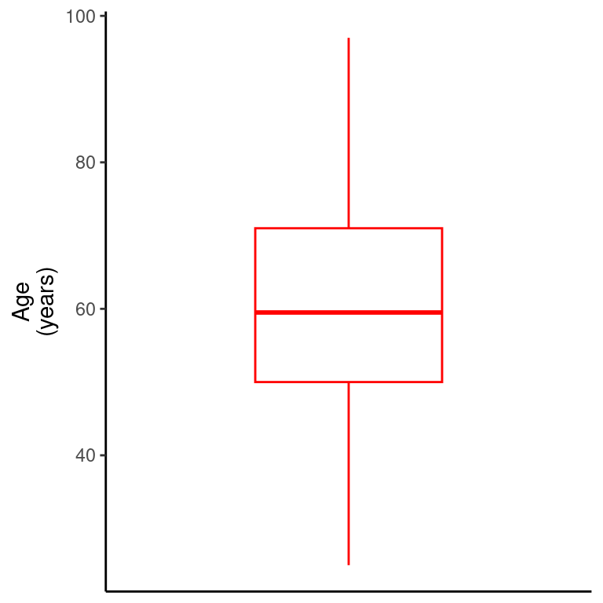

```r
# Check in the age column for the Figure 1A
age_boxplot <- ggplot(table_1, aes(y = Age)) +
  geom_boxplot(color = "red",  outlier.color = "black", outlier.size = 0.8) +
  ylab ("Age\n(years)") +
  scale_x_discrete(labels = NULL) +
  theme_classic()

age_boxplot
```

We see that there are no outliers, so we continue with the objective of this section: represent the figure 1.

### **Represent the data**

To do this part of the exercise, we use the package **cowplot** to represent all the plots and join them in a single figure (with the function **as_grob**).

To reproduce the next figures (B and C), we have to group our data based on the attributes “ARDS Diagnosis”, “Use of NIV” and “Use of AMV”:

- Group 1 (G1) = the three variables are “No”
- Group 2 (G2) = ‘ARDS Diagnosis’ must be No, ‘Use of NIV’ and ‘Use of AMV’ could be “Yes” or “No”
- Group 3 (G3) = Both ‘Use of NIV’ and ‘ARDS Diagnosis’ are both “Yes”, and ‘Use of AMV’ is “No”
- Group 4 (G4) = Both ‘Use of AMV’ and ‘ARDS Diagnosis’ are both “Yes”, and ‘Use of NIV’ could be “Yes” or “No”

```r
# Create the groups

  # We add a new column in the first table to store the patients by the groups we have just defined
table_1$Group = NA

  # In this loop we create the groups for each patient according to the features we have mentioned before

for (i in 1:nrow(table_1)) {
  if ( table_1[i,"Use.of.NIV"] == "No" & table_1[i, "Use.of.AMV"] == "No" & table_1[i,"ARDS.Diagnosis"] == "No" )
  {table_1[i,"Group"] = "G1"}

  else if ((table_1[i,"ARDS.Diagnosis"] == "No") & (table_1[i,"Use.of.NIV"]  == "No" | table_1[i, "Use.of.NIV"] == "Yes") & (table_1[i,"Use.of.AMV"]  == "Yes" | table_1[i, "Use.of.AMV"] == "No"))
    {table_1[i,"Group"] = "G2"}

  else if (table_1[i,"Use.of.NIV"] == "Yes" & table_1[i, "Use.of.AMV"] == "No" & table_1[i,"ARDS.Diagnosis"] == "Yes" )
  {table_1[i,"Group"] = "G3"}

  else if ((table_1[i,"Use.of.AMV"] == "Yes" & table_1[i,"ARDS.Diagnosis"]  == "Yes") & (table_1[i, "Use.of.NIV"] == "Yes" | table_1[i, "Use.of.NIV"] == "No"))
    {table_1[i,"Group"] = "G4" }
  }
```

```r
# Plot B
  # We create the table which will store the information, with 4 columns and 4 rows
figure_1B <- data.frame(matrix(ncol = 4, nrow = 4))

  # Now assign the column names to the table
colnames(figure_1B) <- c("Clinical\nclassification", "NIV", "AMV", "ARDS")

  # Set the corresponding values
figure_1B[1,] <- c("G1", "-", "-", "-")
figure_1B[2,] <- c("G2", "-/+", "+/-", "-")
figure_1B[3,] <- c("G3", "+", "-", "+")
figure_1B[4,] <- c("G4", "-/+", "+", "+")

  # Create the table with the function "tableGrob" and remove the
  # default numbers of the rows with "row = NULL"
table_1B <- tableGrob(figure_1B, rows = NULL)

  # The function "textGrob" allows us to modify the titles
  # and we want it in bold type:
title_bold_1B <- textGrob("Definition of the Clinical Classification", gp=gpar(fontface="bold"))

  # Merge the table and the title and modify the position of them
figure_1B <- grid.arrange(table_1B, top=title_bold_1B, vp=viewport(height=0.8))
```

```r
# Plot C
  # Count the frequency of each group
group_freq <- as.data.frame(table(table_1$Group))
colnames(group_freq) <- c("Group", "Frequency")

  # Bar plots
figure_1C<- as_grob(~barplot(group_freq$Frequency,
        names.arg=group_freq$Group,
        col=c("lightblue", "lightgoldenrod1", "plum3", "indianred2"),
        xlab="Clinical Classification",
        ylab="Frequency (n)",
        main="Clinical Classification",
        ylim=c(0,80),
        cex.main=1))
```

```r
# Plot D
  # Calculate the death frequencies
deaths_freq <- as.data.frame(table(table_1$Death))
colnames(deaths_freq) <- c("Death", "Frequency")

  # Bar plot
figure_1D <- as_grob(~barplot(deaths_freq$Frequency,
        names.arg=deaths_freq$Death,
        col=c("lightblue", "lightgoldenrod1"),
        xlab="Death",
        ylab="Frequency (n)",
        main="Vital status",
        ylim=c(0,180),
        cex.main=1))
```

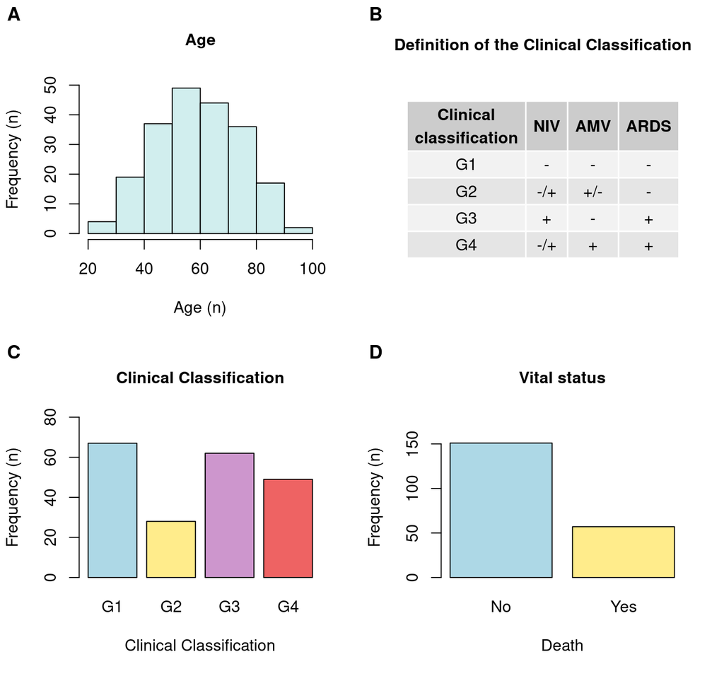

```r
# Complete the Figure 1 by joining all of them

  # we create a list to show all the graph together
figure_1 <- list(figure_1A, figure_1B, figure_1C, figure_1D)

plot_grid(plotlist = figure_1, labels = c("A","B","C","D"))
```

## **2.2. Reproduce Figure 2 from the publication**

*But instead of representing the clusters in the annotation, represent the groups (G1 to G4).*

For this part of the exercise we will use the second table (called “table_2”)

### How is the data of the table_2?

Firstly, we make some adjustments to the table in order to continue with the analysis.

```r
# Modify the name of the first column of table_2 to ID
colnames(table_2)[1] = "ID"

# When we try to calculate the median, some cytokines are not recognized
# because they have the special character ("-"), so we remove it.

table_2 <- table_2 %>% rename_all(funs(gsub("-","",.)))

# Also, substitute all the commas to dots:
table_2[] <- lapply(table_2, function(x) gsub(",", ".", x))

  # "lapply" function is used to apply the gsub function to each column
  # of the table_2 dataframe

# Most of the columns are considered characters, so we change this variables
# to numerical except the IDs (first column)
for (i in 2:ncol(table_2)) {
table_2[,i] <- as.numeric(table_2[,i])
}
```

We have a lot of values of each cytokine because we have measurements for each patient in different days. As they did in the paper, we calculate the median for each patient and each cytokine in order to reduce the complexity of the data.

```r
# We use the summarise function of the library "dplyr"
  # group_by: allows us to group the table_2 by the IDs (called X1 in the table)
  # na.rm = TRUE: missing values are removed before doing the median

table_2_median <- table_2 %>% group_by(ID) %>%
  summarise(IL1β = median(IL1β, na.rm = TRUE), IL6 = median(IL6, na.rm = TRUE),
  IL10 = median(IL10, na.rm = TRUE), IFNɑ = median(IFNɑ, na.rm = TRUE),
  TNFɑ = median(TNFɑ, na.rm = TRUE), IL8 = median(IL8, na.rm = TRUE),
  GCSF = median(GCSF, na.rm = TRUE), IFNγ = median(IFNγ, na.rm = TRUE),
  CCL3 = median(CCL3, na.rm = TRUE), CXCL10 = median(CXCL10, na.rm = TRUE),
  CCL2 = median(CCL2, na.rm = TRUE), IL38 = median(IL38, na.rm = TRUE))
```

Now we want to merge the table_1 that has been modified in the last part of the exercises and this last table_2_median. From the table_1 we extract what we need for this exercise: “ID” and “Group” columns.

```r
# Extract ID and Group columns from table_1
modified_table_1 <- subset(table_1, select = c("ID","Group"))

# Join both tables by the ID
merged_table <- merge(modified_table_1, table_2_median, by="ID")
```

Checking the new table, merged_table, we realize that in column “IL6” there are still NA values and also there are two patients that do not belong to any group. We will run the following command to remove the possible NAs.

```r
table_to_heatmap <- na.omit(merged_table)
```

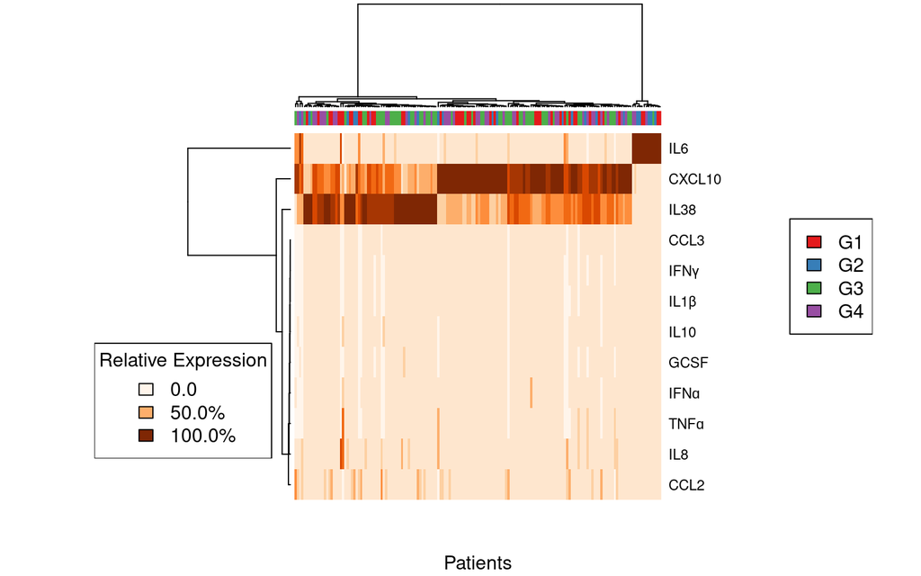

```r
# Vector containing the group to which each patient belongs
Group <- table_to_heatmap$Group

# Set five colors using the function of the "RColorBrewer" package
colors <- brewer.pal(4, "Set1")

# Create a vector in which each patient is a color depending on the group to
# which they belong
list_of_colors <- ifelse(Group == "G1", colors[1],
                   ifelse(Group == "G2", colors[2],
                   ifelse(Group == "G3", colors[3],
                   ifelse(Group == "G4", colors[4], NA))))

# Create the heatmap
heatmap(as.matrix(t(table_to_heatmap[,3:14])), cexCol = 0.1, xlab = "Patients", labCol = FALSE,
        col = brewer.pal(9,"Oranges"), scale = "column", ColSideColors = list_of_colors)

# Modify the legends
legend("right",legend=c("G1", "G2", "G3", "G4"),fill=colors)
legend("bottomleft", legend = c("0.0", "50.0%", "100.0%"),
       fill = (brewer.pal(9,"Oranges")[c(1,4,9)]),
       title = "Relative Expression")
```

As they state in the paper, we also didn’t find an association with the 4 groups of clinical classification and the different values for the gene expression.

## **2.3. Improve figure 2 of the publication**

*Add a second annotation with information of death and a third one with information of gender.*

For this last part of the exercise we use the package [**ComplexHeatmap**](https://www.bioconductor.org/packages/release/bioc/html/ComplexHeatmap.html) which allows us to create a single heatmap with different sources of data sets. This is our goal here, we want to add to the previous heatmap information about the variables “Death” and “Gender”.

```r
# Extract from the table_1 the columns we need for the exercise
table_1_second_heatmap <- subset(table_1, select = c("ID","Gender","Death", "Group"))

# When we do the heatmap we found the problem that for the characters
# (alpha,beta,gamma) are not recognized so we obtain a lot of warnings

new_table_2_median <- table_2_median

colnames(new_table_2_median) <- gsub("ɑ", "alpha", colnames(new_table_2_median))
colnames(new_table_2_median)  <- gsub("γ", "gamma", colnames(new_table_2_median))
colnames(new_table_2_median) <- gsub("β", "beta", colnames(new_table_2_median))


# Join both tables by the ID
second_merged_table <- merge(table_1_second_heatmap, new_table_2_median, by="ID")

# As before we remove all the NAs values
table_to_second_heatmap <- na.omit(second_merged_table)
```

```r
Group_2 <- table_to_second_heatmap$Group
Death <- table_to_second_heatmap$Death
Gender <-table_to_second_heatmap$Gender

Group_annotation <- HeatmapAnnotation(Group =  Group_2, col = list(Group = c("G1" = "red", "G2" = "blue", "G3" = "green", "G4" = "purple" )))
Death_annotation <- HeatmapAnnotation(Death =  Death, col = list( Death = c("Yes" = "gray16", "No" = "lightskyblue2")))
Gender_annotation <- HeatmapAnnotation(Gender =  Gender, col = list(Gender = c("F" = "magenta", "M" = "yellow")))

# Create the variable matrix_data which we
# will use to do the heatmap
matrix_data <-as.matrix(t(table_to_second_heatmap[,5:16]))

# Normalize the data
matrix_data_normalized <- scale(matrix_data)
```

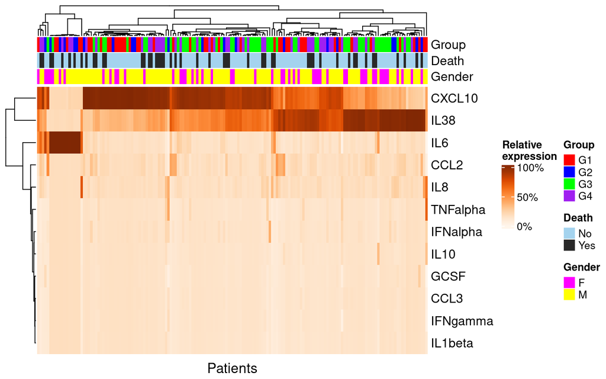

```r
# Do the heatmap
Heatmap(matrix_data_normalized,
        top_annotation = c(Group_annotation, Death_annotation, Gender_annotation),
        col = brewer.pal(9,"Oranges"),
        show_column_names = FALSE, column_title = "Patients", column_title_side= "bottom" ,
        show_heatmap_legend = TRUE,
        heatmap_legend_param = list(title = "Relative\nexpression",
                                    at = c(-1,1,3),
                                    labels = c("0%","50%","100%")))
```

We also don’t find any apparent association with the clinical groups, the gender or whether or not the person has died with the different values for the gene expression.

# session info

R version 4.1.2 (2021-11-01) Platform: x86_64-pc-linux-gnu (64-bit) Running under: Linux Mint 21

Matrix products: default BLAS: /usr/lib/x86_64-linux-gnu/blas/libblas.so.3.10.0 LAPACK: /usr/lib/x86_64-linux-gnu/lapack/liblapack.so.3.10.0

locale: [1] LC_CTYPE=en_US.UTF-8 LC_NUMERIC=C  
[3] LC_TIME=en_US.UTF-8 LC_COLLATE=en_US.UTF-8  
[5] LC_MONETARY=es_ES.UTF-8 LC_MESSAGES=en_US.UTF-8  
[7] LC_PAPER=es_ES.UTF-8 LC_NAME=C  
[9] LC_ADDRESS=C LC_TELEPHONE=C  
[11] LC_MEASUREMENT=es_ES.UTF-8 LC_IDENTIFICATION=C

attached base packages: [1] grid stats graphics grDevices utils datasets methods  
[8] base

other attached packages: [1] ComplexHeatmap_2.10.0 RColorBrewer_1.1-3 gridExtra_2.3  
[4] openxlsx_4.2.5.1 GGally_2.1.2 tidyr_1.3.0  
[7] mice_3.15.0 cowplot_1.1.1 ggthemes_4.2.4  
[10] dplyr_1.1.0 ggplot2_3.4.0